# 中美贸易摩擦会影响企业市场进入吗？

刘越冬

2019/3/1

[返回主页](http://yuedong.site)

### **摘要**

*入世以来，凭借着在国际贸易中的比较优势，我国出口份额占全球比重不断提升，然而伴随着近些年国际上出现的逆全球化势力，不断增加的国际贸易争端势必会对我国经济造成影响。另一方面，企业作为一国经济活动的主体，其市场进入不仅影响经济的运行，同时也反映者经济运行状况，因此研究贸易争端对我国经济影响，企业的市场进入将是一个很好的切入点。*

#### *本文在文献研究的基础上，通过实证研究，在控制住生产价格指数、固定资产投资完成额度等变量的影响后，发现贸易摩擦与外资企业进入存在正向关系，而与其他类型企业的市场进入关系不显著。同时在贸易摩擦对部分国家（地区）实际利用外资的影响估计中发现，中美间的贸易争端并没有使美国加大对中国的对外投资，而地缘关系复杂的日本可能为了避免风险加大了对中国的投资。*

[figure not shown]

### **正文**

#### *研究背景*

随着我国在国际贸易中的占比逐年提升，与别国的贸易冲突也不断增多。2017年8月美国贸易代表办公室宣布对中国发起301调查，此后中美之间的贸易摩擦不断升温。纵观中美贸易冲突整个发展历程，美国共对中国加征超过2500亿美元商品的关税，而根据中国商务部数据，2017年全年美国自中国进口5056亿美元商品，贸易摩擦导致的关税占比近半。

另一方面，企业是一国经济活动的主体，其市场进入不仅影响经济的运行，同时也反映着经济运行状况。自从中国加入世界贸易组织以来，我国对外资进入的限制不断放宽，凭借优惠的政策支持和廉价劳动力成本等因素，我国吸引了大量外商直接投资，据中国商务部统计，2017年，全国各行业实际使用外资达到1363.2亿美元，同比增长2%，位居全球第二。学界对国际贸易和直接投资的研究始于上世纪50年代，两者的关系由单一替代发展到替代与互补并存，中美贸易体量巨大，不断升级的中美贸易摩擦对我国外来直接投资必然产生影响，而这也会对其他类型企业的市场进入产生间接影响

国内针对国际贸易和FDI的研究已有二十余年，然而大部分文献多关注国际贸易和FDI的关系或单独地研究FDI的区位选择，却很少有针对国际贸易对不同企业类型影响差异的研究，当前我国不同所有制经济混合发展，为经济发展注入了活力，面对日益升级的贸易争端，研究其受影响的差异就显得十分重要。

基于以上分析，提出本文的主要研究问题，即中美贸易摩擦是否确实对外资企业进入产生影响，以及对不同类型的企业是否有不同的影响。

#### *研究目的及意义*

本文的研究目的立在通过文献研究的回顾和实证研究，从企业成立数量这一关键指标出发，探究中美贸易战期间外资企业市场进入的趋势变化，在控制住以往文献中出现的关键变量后，检验贸易争端是否确实对外资企业进入产生影响，以及对不同类型的企业是否有不同的影响，这对深入理解现阶段我国国际贸易状况和不同类型企业市场进入的关系以及评估经济政策具有重要现实意义。

#### *文献回顾*

1. *国际贸易和FDI理论*
- *国际投资理论*

> 完全竞争的市场是资本运动理论在发展初期的假设条件，该理论将国际资本流动归结于利率差别，然而近些年来，随着国际投资实践和理论的发展，原先的理论已经无法对新出现的情况进行解释。20世纪60年代，美国学者Hymer（1976）在分析跨国公司投资行为的基础上，提出了垄断优势理论，该理论认为：FDI的产生源于市场的结构性失衡，比如技术和知识独占导致的不完全竞争；企业在这种条件下获得的各种垄断优势，如技术优势、规模经济优势、资金和货币优势、组织管理能力的优势，使得该企业有动机进行对外直接投资；并且这样也可以更好的维护其在被投资国的垄断地位<sup>1</sup>。

> 到了20世纪70年代，FDI理论的研究逐渐与新制度经济学理论相结合，Rugman（1980）在总结前人理论的基础上，从科斯的产权理论出发，提出了内部优势理论。他认为市场信息条件的不完全使得企业为了规避交易成本而将市场由本国扩大到别国，于是就产生了对外投资<sup>2</sup>。Dunning（1992）的国际生产折衷理论将前人的理论综合起来，同时用国际贸易理论、区位理论和“内部化”理论一起来解释外商直接投资<sup>3</sup>。这一理论认为跨国公司一般有两个优势，即所有权优势和内部化优势，而东道国应拥有区位优势，这三个前提条件成为了企业对外投资必备的基础。国际生产折衷理论为FDI的研究提供了一般化的框架，如Boddewyn（1983）在此基础上进一步研究了跨国公司撤资问题，认为优势的丧失是跨国公司撤资的直接动因<sup>4</sup>。
- *国际贸易和FDI关系*

> 学界针对外商直接投资与对外贸易之间关系的理论也不断发展，二者的关系最初为单一的替代或互补关系，在理论发展后期二者则出现了替代和互补共存，相互影响，相互发展的关系。

> Mundell（1957）作为研究国际贸易的关键人物，提出了关税引致投资（Tariff-induced Investment）这一概念，他将传统的H-O理论的分析框架作为理论基础，认为在自由贸易条件下，两国间的生产要素可以自由流动，这样就不会产生跨国投资；然而在出现贸易壁垒的情况下，如果厂商实施跨国直接投资，那么这种跨国直接投资在一定程度上可以实现对商品贸易的替代<sup>5</sup>。

> Markuson和Svensson(1985)认为对外投资和贸易壁垒存在一种互补关系，如果资本的流动和关税没有关系，而且其主要流向出口部门而不是进口部门，那么投资和贸易之间就将表现为一种互补关系而不是替代关系。该理论基本思路为：由于技术上存在差异，两个国家彼此之间的要素生产率和要素价格也会不同,从而引起商品贸易和要素的国际流动<sup>6</sup>。

> Bhagwati和Dinopoulos（1987）从政治经济学的角度出发，提出了补偿投资模型。该理论认为，要素价格不同等经济因素造成的贸易障碍并不能单纯地解释投资和贸易之间的关系，在存在贸易保护主义的国际关系中，不同政治集团间利益的博弈也会导致投资出现增长，即补偿投资。和关税引致的投资不同，补偿投资是为了化解东道国采取贸易保护的措施，因此也称为化解关税投资<sup>7</sup>。

#### 2. *关于企业进入和区位选择的研究综述*

> 企业的进入退出和地区产业的更新与经济的发展具有密不可分的关系，因此，西方学者对企业进入的区位选择进行了大量研究，解释框架先后经历了新古典主义、行为主义、制度主义与演化主义4个阶段<sup>8</sup>。传统新古典主义理论将成本收益作为衡量经济决策的依据，在强调自然资源、劳动力、技术等要素成本是企业进行决策的指标外，也十分关注市场规模与潜力对产业活动区块选择的重要作用。20世纪80年代后，随着西方去工业化过程的深化，很多国家经历了传统工业区的衰落与高科技产业的兴起，地区失业率、人力资本、区域创新能力成为企业动态研究的重点(Storey,1991<sup>9</sup>)。与此同时，部分学者用地方文化与企业家精神、制度等因素对企业的空间动态进行解释([Bartik,1989]))<sup>10</sup>。
- *国际间资本流动相关研究*

> 自上世纪70年代以来，不断有学者针对外国直接投资区位选择进行研究，这一过程主要分为两个阶段，早期阶段的理论主要从传统区位理论-即成本收益分析来分析外国直接投资的区位选择，后期随着新制度经济学的发展，传统的区位理论将科斯的交易成本概念加入其分析中，新的理论认为国际投资的区位选择取决于交易成本的高低，如Caves(1971)认为，和本土公司不同，外来资本在选择投资区位时，需要考虑当地生产投入预估量、考察当地市场潜力、技术劳工成本以及管理结构的搭建效率等方面的因素，这使导致外商采用风险回避的策略，从而选择交易成本较低的区位<sup>11</sup>。

> 随后的研究多将古典区位因素和制度文化因素一起考虑，如Tatoglu和Glaister（1998）发现，除了市场规模大小、经济增长快慢、原材料和劳动力供应能力、产业竞争程度、地理接近程度、交通运输成本以及东道国的基础设施等因素外，政治和法律环境稳定程度、东道国政策等因素也是决定外商直接投资区位选择的重要考察指标<sup>12</sup>。20世纪90年代区位选择理论将社会、文化、制度等因素纳入到其研究中（刘作丽，贺灿飞，2009<sup>13</sup>），如鲁明泓（1997）的实证研究发现，国际资本在流动时会考虑流入国的国际经济安排、经济制度、法律制度和企业运行便利性，一般来讲，FDI倾向于流入对外资持欢迎态度、经济自由度高、自有财产保护度高、法律完善、企业运行障碍少、政府清廉程度高的国家或地区<sup>14</sup>。

> 随着FDI理论的发展，Dunning（1992）在借鉴上述理论的基础上，把跨国公司的投资动机分为资源导向型、市场导向型、效率导向型和战略导向型四大类，他认为投资动机和区位的选择具有紧密的关系：如资源导向型投资往往是为了获取自然资源、廉价劳动力，这类企业在进行区位选择时要考虑的首要因素是成本大小；市场导向型投资是为了跟随供应链、追随竞争者、节省交易成本和适应本地需求，这类企业在进行区位选择时要考虑的首要因素往往是市场规模、市场潜力、商业网络、市场竞争等因素；效率导向型投资是要依据要素禀赋进行全球布局生产，或是利用规模与范围经济进行布局，这类类企业在进行区位选择时主要考虑是否可以产生聚集效应<sup>15</sup>。
- *外商对华投资相关研究*

> 在华FDI区位研究始于20世纪80年代未90年代初，学者一般从两个方面入手进行研究，一个是研究中国和外国在吸引外资上区位因素有哪些差异，另一个是研究中国内部区域间的要素差异，研究内容一般为东中西区域差异，省区差异以及城乡差异。 有研究从传统的区位选择理论出发，对区位因素进行研究和对比。武超（1991）认为：外商直接投资更青睐政治相对稳定、市场潜力大、劳动费用低以及独立、完善、产业结构丰富的经济体<sup>16</sup>。Fung、Iizaka、Lee和Paker(2000)通过使用中国各省份1991-1997年GDP、工资、公路通车里程和铁路通车里程等样本所组成的面板数据，将美国对华投资和日本对华投资进行对比，他发现：GDP、工资率、劳动者素质和开发区、开放城市的数量影响外商对华直接投资数量<sup>17</sup>。魏后凯、贺灿飞、王新（2001）将东道国地区位因素概括为两大类，一类为资源禀赋，包括自然资源、劳动力资源和接近市场状况，另一类为东道国的政治、经济、法律以及基础设施等相关的环境因素，他们认为产业类型、是否出口等因素直接决定了外资来华投资的动机，因此也决定了其在区位选择时考虑的因素<sup>18</sup>。

> 有研究从国际资本移动的动机出发，分析动机差异对外商投资区位选择的影响。梁琦、施晓苏（2004）将国际资本移动的动机分为三大类：资源导向型、成本驱动型、市场拉动型。来自港澳台的投资动机往往是利用丰富的资源和廉价的劳动力，其产品以远销中国以外的市场为主，在我国的出口中占比较大<sup>19</sup>。

> 有学者从交易成本的角度进行分析，刘作丽、贺灿飞（2009）认为，外国投资者与东道国企业相比，在购买原材料、发现市场机会、获取熟练劳动力以及许多不可预见的不确定性方面要比东道国企业承担更多的风险和支付更高的信息成本，因此，FDI区位选择通常是对信息成本的一种理性反映<sup>20</sup>。

> 另一些研究表明在研究劳动力因素时，单纯的劳动力成本无法成为准确衡量外商对华投资的标准，因为劳动力成本同时也是生产力和技能的重要指标，因此只有有效控制了劳动生产率后工资水平才具有可比较性。Wei（1999）利用效率工资研究发现FDI会避开效率工资较高的省份<sup>21</sup>，鲁明泓（1997）在将劳动生产率纳入模型中估计后发现省区的劳动力成本与FDI之间存在负向关系<sup>39</sup>，Cheng（2006）也认为劳动力素质是影响企业区位选择的重要因素<sup>22</sup>。

> 从区位因素局部差异看，Zhang(2001)指出东部沿海企业主要是出口导向的，而中西部地区企业更偏向于固定资产投资，在FDI比重较高的沿海地区，FDI和出口企业往往是互补关系；在FDI占比中等的地区，FDI更看重该地企业的出口潜力；在FDI占比较低的地区，FDI在该地往往对出口起到决定性作用[23]。类似地，Luo(2001)发现经济特区和沿海开放城市等制度变量在FDI区位选择中具有显著的影响作用<sup>24</sup>。最后，贺灿飞,魏后凯(2001)发现，信息成本同样在中国存在区域差异，FDI的区位选择通常是对信息成本的一种理性反应，外商更倾向于在政府透明、法律完善、市场公开的地区进行投资<sup>25</sup>。

#### *中美贸易摩擦简述*

中美贸易关系自建立以来就一直伴随着波折和冲突，近年随着美国保护主义的抬头，两国间的贸易关系又一次遇到了考验。从事件发展上看，此次中美贸易摩擦分为两个部分，分别是中美双方博弈阶段和冲突正式爆发阶段。纵观中美贸易摩擦整个发展历程可以看出，正式实施的关税政策有三次，第一次是特朗普签署对华贸易备忘录，对钢铁和铝加征关税，并且中国进行反击；第二次是7月和8月针对500亿美元的两次加征关税；第三次是9月24日美国对中国的2000亿美元商品加征关税和中对美600亿美元加征关税。可以发现在上半年，除了在3月份小额的互征关税外，并没实际上实施其他关税政策，到了下半年7月份贸易战正式开始两国才正式实施政策。

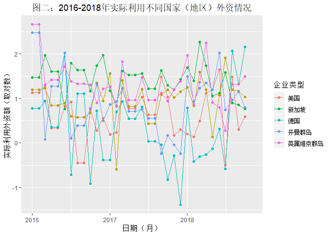

#### *描述性统计*

为了探究贸易摩擦对不同类型企业的影响差异，本小节使用了来自国家统计局、中国商务部、中国经济景气月报数据。经过处理后，得到截至2018年11月共35个月的观测值，具体变量包括中外合资企业、中外合作企业、外资企业、民营企业和国有企业各自的企业新增数、外资利用额、当期进出口额，另外包括每月的生产价格指数、上年固定资产投资完成额，并且按照2018年3月为时间节点设置了贸易摩擦是否发生的虚拟变量。其中，企业新增数可以较好地体现企业市场进入的状况；外资利用额可以衡量国外资金对华投资的状况；当期出口额可以体现国际贸易状况；生产价格指数和固定资产投资完成额则作为基本指标体现我国经济运行状况和基础设施水平。

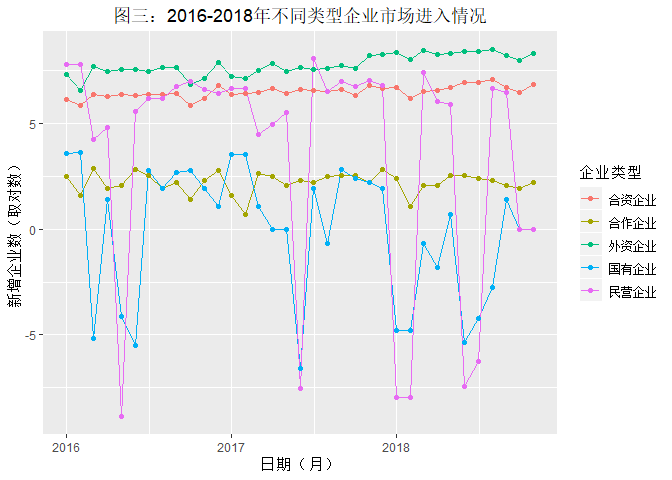

#### *模型估计分析*

本文主要探究中美之间的贸易摩擦对我国不同类型企业市场进入影响的差异性，研究主体在于两点，一是强调贸易摩擦特指中国与美国之间产生的摩擦；二是强调贸易摩擦对市场进入的影响，因此首先本文将探究企业市场进入在贸易摩擦前后的差异性，其次再考虑贸易摩擦的中美特指性。在参考以往文献的基础上，本节使用了带有二期滞后项的时间序列模型分别对不同企业类型企业每月成立数量进行估计，其中newf表示每月新增企业数，import表示当期进口数量，export表示当期出口数量，PPI表示生产价格指数、investment表示上年固定资产投资完成额、tradewar_trariff表示贸易摩擦是否发生的虚拟变量，其时间节点为2018年3月，原因在于当时美国根据301调查的结果，开始对我国加征关税，并限制中国企业对美投资并购，并且中国也采取了相应措施，尽管此次互征关税数量不高，但却是两国正式将关税政策加以实施的节点，因此本节将此时间节点作为判定贸易摩擦的虚拟变量。模型表示如下：

> $newf(t)=β0+β1import(t)+β2export(t)+β3PPI(t)+β4investment(t)+$ $β5tradewar_tariff(t)+β6tradewar_tariff(t-1)+β7tradewar_tariff(t-2)+u(t)$

**表一：贸易摩擦对外资企业进入的影响**

|  | *Dependent variable:* |  |  |  |  |  |
| --- | --- | --- | --- | --- | --- | --- |
|  | newf_forecap |  |  |  |  |  |
|  | (1) | (2) | (3) | (4) | (5) | (6) |
| import_forecap | 0.0001** | 0.0001** | 0.0001** |  | 0.0001** | 0.0001* |
|  | (0.00004) | (0.00004) | (0.00004) |  | (0.00004) | (0.00005) |
| export_forecap | 0.00001 | 0.00002 | -0.00001 |  | -0.00001 | 0.00003 |
|  | (0.00004) | (0.00004) | (0.00004) |  | (0.00003) | (0.00005) |
| PPI | -24.657 |  |  | 43.180 |  | -31.507 |
|  | (29.998) |  |  | (29.564) |  | (32.770) |
| investment | -0.019* | -0.018 |  | 0.003 |  | -0.022* |
|  | (0.011) | (0.011) |  | (0.010) |  | (0.013) |
| tradewar_tariff | 1,284.365*** | 1,372.295*** | 2,006.992** | 1,973.938*** | 1,287.697*** | 2,075.263** |
|  | (360.536) | (342.369) | (758.484) | (358.571) | (325.810) | (770.408) |
| L(tradewar_tariff) |  |  | -634.773 |  |  | -704.468 |
|  |  |  | (1,008.563) |  |  | (1,004.706) |
| L(tradewar_tariff, 2) |  |  | -229.170 |  |  | -161.809 |
|  |  |  | (773.566) |  |  | (777.509) |
| Constant | -341.778 | -2,342.316* | -1,881.559 | -2,450.515 | -1,645.704 | 512.651 |
|  | (2,703.380) | (1,170.064) | (1,415.898) | (3,015.012) | (1,083.523) | (3,173.015) |
| Observations | 34 | 34 | 33 | 34 | 35 | 32 |
| R<sup>2</sup> | 0.733 | 0.726 | 0.698 | 0.578 | 0.715 | 0.724 |
| Adjusted R<sup>2</sup> | 0.685 | 0.689 | 0.643 | 0.536 | 0.687 | 0.643 |
| *Note:* | p<0.1; p<0.05; p<0.01 |  |  |  |  |  |

**表二：贸易摩擦对合资企业进入的影响**

|  | *Dependent variable:* |  |  |  |  |  |
| --- | --- | --- | --- | --- | --- | --- |
|  | newf_jointcap |  |  |  |  |  |
|  | (1) | (2) | (3) | (4) | (5) | (6) |
| import_jointcap | 0.0001** | 0.0001*** | 0.0001*** |  | 0.0001*** | 0.0001** |
|  | (0.00002) | (0.00002) | (0.00002) |  | (0.00002) | (0.00002) |
| export_jointcap | -0.00003 | -0.00003* | -0.00003* |  | -0.00003 | -0.00003 |
|  | (0.00002) | (0.00002) | (0.00002) |  | (0.00002) | (0.00002) |
| PPI | 4.967 |  |  | 13.425** |  | 4.361 |
|  | (5.193) |  |  | (4.882) |  | (5.716) |
| investment | 0.001 | 0.001 |  | 0.003* |  | 0.001 |
|  | (0.002) | (0.002) |  | (0.002) |  | (0.002) |
| tradewar_tariff | 87.915 | 72.793 | -31.175 | 183.468*** | 104.335* | -31.300 |
|  | (62.070) | (59.934) | (123.681) | (59.213) | (56.176) | (128.118) |
| L(tradewar_tariff) |  |  | -27.872 |  |  | -18.536 |
|  |  |  | (170.111) |  |  | (175.530) |
| L(tradewar_tariff, 2) |  |  | 219.181 |  |  | 189.893 |
|  |  |  | (129.241) |  |  | (135.253) |
| Constant | -514.996 | -85.324 | 67.946 | -885.481* | -114.068 | -349.352 |
|  | (492.625) | (201.839) | (228.450) | (497.884) | (198.864) | (583.637) |
| Observations | 34 | 34 | 33 | 34 | 35 | 32 |
| R<sup>2</sup> | 0.632 | 0.620 | 0.622 | 0.509 | 0.617 | 0.621 |
| Adjusted R<sup>2</sup> | 0.566 | 0.568 | 0.552 | 0.460 | 0.580 | 0.510 |
| *Note:* | p<0.1; p<0.05; p<0.01 |  |  |  |  |  |

*表2为贸易摩擦对中外合资企业进入影响的估计结果，从模型（1）到模型（5）中可以发现，在控制住所有变量后，贸易摩擦虚拟项不显著，但在去掉进出口额控制项后，贸易摩擦虚拟项显示为在1%的水平上显著，这可能是由于进出口额与贸易摩擦项之间存在相关性，导致其估计结果不准确，同时生产价格指数在5%的水平上正向显著。在检验非滞后项与滞后两期变量联合显著性时，其p值为0.3064，显示其联合不显著。*

**表三：贸易摩擦对合作企业进入的影响**

|  | *Dependent variable:* |  |  |  |  |  |
| --- | --- | --- | --- | --- | --- | --- |
|  | newf_coop |  |  |  |  |  |
|  | (1) | (2) | (3) | (4) | (5) | (6) |
| import_coop | 0.00000 | 0.00000 | 0.00001 |  | 0.00001 | 0.00001 |
|  | (0.00001) | (0.00001) | (0.00002) |  | (0.00001) | (0.00002) |
| export_coop | 0.00001 | 0.00001 | 0.00001* |  | 0.00002** | 0.00000 |
|  | (0.00001) | (0.00001) | (0.00001) |  | (0.00001) | (0.00001) |
| PPI | -0.069 |  |  | -0.087 |  | -0.026 |
|  | (0.142) |  |  | (0.130) |  | (0.166) |
| investment | 0.0001* | 0.0001* |  | 0.0001*** |  | 0.0001* |
|  | (0.0001) | (0.0001) |  | (0.00004) |  | (0.0001) |
| tradewar_tariff | -2.351 | -2.414 | -3.516 | -2.223 | -1.651 | -3.625 |
|  | (1.629) | (1.602) | (4.151) | (1.575) | (1.521) | (4.091) |
| L(tradewar_tariff) |  |  | -0.048 |  |  | 0.958 |
|  |  |  | (5.950) |  |  | (5.911) |
| L(tradewar_tariff, 2) |  |  | 2.563 |  |  | 0.549 |
|  |  |  | (4.240) |  |  | (4.345) |
| Constant | 6.224 | -0.854 | -3.674 | 12.786 | -3.791 | 0.922 |
|  | (16.001) | (6.330) | (6.959) | (13.244) | (6.126) | (19.162) |
| Observations | 34 | 34 | 33 | 34 | 35 | 32 |
| R<sup>2</sup> | 0.271 | 0.265 | 0.174 | 0.254 | 0.179 | 0.291 |
| Adjusted R<sup>2</sup> | 0.141 | 0.163 | 0.021 | 0.179 | 0.100 | 0.084 |
| *Note:* | p<0.1; p<0.05; p<0.01 |  |  |  |  |  |

*表3为贸易摩擦对中外合作企业进入影响的估计结果，从模型（1）到模型（5）中可以发现，在控制住所有变量后，贸易摩擦虚拟项不显著，但在去掉进出口额控制项后，上年固定资产投资完成额显示为在1%的水平上显著，表明固定资产投资对吸引中外合作企业具有正向促进作用。*

**表四：贸易摩擦对民营企业进入的影响**

|  | *Dependent variable:* |  |  |  |  |  |
| --- | --- | --- | --- | --- | --- | --- |
|  | newf_private |  |  |  |  |  |
|  | (1) | (2) | (3) | (4) | (5) | (6) |
| import_private | 0.00001 | 0.00003 | 0.0001 |  | 0.00003 | 0.0001 |
|  | (0.0001) | (0.0001) | (0.0001) |  | (0.0001) | (0.0001) |
| export_private | -0.00003 | -0.00003 | -0.00005 |  | -0.00003 | -0.0001 |
|  | (0.00004) | (0.00004) | (0.00005) |  | (0.00004) | (0.00005) |
| PPI | 33.456 |  |  | 22.800 |  | 101.833 |
|  | (86.545) |  |  | (69.027) |  | (87.496) |
| investment | -0.001 | -0.002 |  | -0.008 |  | 0.032 |
|  | (0.027) | (0.026) |  | (0.023) |  | (0.028) |
| tradewar_tariff | 299.004 | 107.575 | -799.422 | 137.236 | 107.806 | -248.609 |
|  | (1,266.344) | (1,147.668) | (2,667.359) | (875.734) | (1,127.798) | (2,761.214) |
| L(tradewar_tariff) |  |  | 722.887 |  |  | 563.996 |
|  |  |  | (3,094.437) |  |  | (3,124.433) |
| L(tradewar_tariff, 2) |  |  | -857.126 |  |  | -1,002.630 |
|  |  |  | (2,085.169) |  |  | (2,093.236) |
| Constant | -1,147.209 | 1,758.606 | -1,146.707 | -1,787.913 | 1,762.073 | -10,900.770 |
|  | (7,916.111) | (2,444.174) | (2,950.337) | (7,039.492) | (2,401.362) | (8,568.462) |
| Observations | 33 | 33 | 31 | 33 | 33 | 31 |
| R<sup>2</sup> | 0.037 | 0.032 | 0.094 | 0.007 | 0.032 | 0.172 |
| Adjusted R<sup>2</sup> | -0.141 | -0.107 | -0.087 | -0.096 | -0.069 | -0.080 |
| *Note:* | p<0.1; p<0.05; p<0.01 |  |  |  |  |  |

*表4为贸易摩擦对民营企业进入影响的估计结果，从模型（1）到模型（5）中可以发现，在控制住所有变量后，贸易摩擦虚拟项不显著，在去掉其他控制项后，贸易摩擦虚拟项均不显著。在检验非滞后项与滞后两期变量联合显著性时，其p值为0.7287，显示其联合不显著。这表明贸易摩擦对我国民营企业的市场进入没有显著影响。*

**表五：贸易摩擦对国有企业进入的影响**

|  | *Dependent variable:* |  |  |  |  |  |
| --- | --- | --- | --- | --- | --- | --- |
|  | newf_sate |  |  |  |  |  |
|  | (1) | (2) | (3) | (4) | (5) | (6) |
| import_state | -0.00001 | -0.00000 | 0.00000 |  | -0.00000 | -0.00001 |
|  | (0.00001) | (0.00001) | (0.00001) |  | (0.00001) | (0.00001) |
| export_state | 0.00001 | 0.00000 | -0.00001 |  | -0.00001 | 0.00001 |
|  | (0.00002) | (0.00002) | (0.00002) |  | (0.00002) | (0.00002) |
| PPI | 6.885 |  |  | 1.333 |  | 6.671 |
|  | (7.719) |  |  | (4.957) |  | (8.390) |
| investment | -0.003* | -0.003* |  | -0.003* |  | -0.004 |
|  | (0.002) | (0.002) |  | (0.002) |  | (0.002) |
| tradewar_tariff | 133.710 | 74.312 | 59.777 | 46.847 | 49.801 | 158.236 |
|  | (110.962) | (88.439) | (172.305) | (62.884) | (90.412) | (184.139) |
| L(tradewar_tariff) |  |  | 5.247 |  |  | -11.790 |
|  |  |  | (218.982) |  |  | (214.845) |
| L(tradewar_tariff, 2) |  |  | -45.188 |  |  | 1.701 |
|  |  |  | (169.890) |  |  | (168.935) |
| Constant | -422.248 | 170.314 | 123.687 | -27.683 | 179.583 | -353.103 |
|  | (701.610) | (225.002) | (289.714) | (505.486) | (232.877) | (784.788) |
| Observations | 33 | 33 | 31 | 33 | 33 | 31 |
| R<sup>2</sup> | 0.153 | 0.128 | 0.024 | 0.124 | 0.032 | 0.138 |
| Adjusted R<sup>2</sup> | -0.004 | 0.003 | -0.171 | 0.033 | -0.068 | -0.124 |
| *Note:* | p<0.1; p<0.05; p<0.01 |  |  |  |  |  |

*表5为贸易摩擦对国有企业进入影响的估计结果，从模型（1）到模型（5）中可以发现，在控制住所有变量后，贸易摩擦虚拟项不显著，在模型（1）与模型（2）中可以发现上年固定资产投资完成额的p值符合显著性水平，但在考虑到贸易摩擦虚拟项与进出口额之间可能存在的相关性，并且在与模型（4）进行对比后，可以认为该控制项对国有企业的进入不存在显著影响。在检验非滞后项与滞后两期变量联合显著性时，其p值为0.9441，显示其联合不显著。*

#### 分析小结

综上可以发现，贸易摩擦虚拟项与外资企业的市场进入存在显著的正向关系，而与其他类型企业的市场进入关系不显著。尽管如此，以上结果仍不足以说明本文的主题。本文探究的问题是中美贸易摩擦对不同类型企业市场进入的差异，首先关注点在于中美贸易摩擦这个事件，而上文中所使用的虚拟项不一定特指中美贸易摩擦事件，因此无法说明本文的主题。为了说明上述问题，下文第四部分将对中美贸易摩擦期间我国外资利用额变化情况进行描述；其次，以上结果无法说明外资进入的前后差异是否确实为贸易摩擦所导致。从以往的文献中可以发现，针对贸易和外资流动的研究其考察的对象均为贸易当事国，那么如果以上结论均成立，中美贸易摩擦对外资造成的影响也应针对美国的企业，本文已下部分将对此进行说明。

#### 进一步探究

本节使用了时间序列模型分别对不同国家（地区）外资实际利用额进行估计，其中country_newcap表示每月新增实际利用外资金额，PPI表示生产价格指数、investment表示上年固定资产投资完成额、tradewat_trariff表示贸易摩擦是否发生的虚拟变量，其时间节点为2018年3月，模型表示如下：

> $country_newf(t)=β0+β1PPI(t)+β2investment(t)+β3tradewar_tariff(t)+u(t)$

**表六：贸易摩擦对部分国家（地区）实际利用外资影响**

|  | *Dependent variable:* |  |  |  |  |  |
| --- | --- | --- | --- | --- | --- | --- |
|  | US_newcap | JP_newcap | SG_newcap | GM_newcap | KM_newcap | VK_newcap |
|  | (1) | (2) | (3) | (4) | (5) | (6) |
| PPI | -0.012 | 0.016 | -0.062 | -0.103 | -0.255*** | -0.266*** |
|  | (0.041) | (0.041) | (0.060) | (0.073) | (0.082) | (0.085) |
| investment | 0.00001 | -0.00001 | -0.00000 | 0.00002 | -0.0001** | -0.0001*** |
|  | (0.00001) | (0.00001) | (0.00002) | (0.00002) | (0.00003) | (0.00003) |
| tradewar_tariff | 0.471 | 1.044** | -0.300 | 1.226 | 1.615 | 0.885 |
|  | (0.502) | (0.502) | (0.726) | (0.891) | (0.995) | (1.029) |
| Constant | 2.574 | 1.594 | 10.902* | 11.593 | 32.283*** | 35.775*** |
|  | (4.222) | (4.221) | (6.108) | (7.489) | (8.362) | (8.650) |
| Observations | 34 | 34 | 34 | 34 | 34 | 34 |
| R<sup>2</sup> | 0.092 | 0.132 | 0.045 | 0.137 | 0.373 | 0.427 |
| Adjusted R<sup>2</sup> | 0.001 | 0.045 | -0.050 | 0.051 | 0.310 | 0.370 |
| *Note:* | p<0.1; p<0.05; p<0.01 |  |  |  |  |  |

*表六为贸易摩擦对部分国家（地区）实际利用外资影响估计结果，从估计结果可以发现，在控制住生产价格指数、上年固定资产投资完成额后，贸易摩擦对日本的实际利用外资额具有显著的正向关系，说明中美贸易摩擦使得日本的外资企业更愿意进入中国；而其他模型中贸易摩擦均不显著，其中美国的估计结果显示，尽管美国的实际利用外资额的时间变动符合两国贸易摩擦事件的时间线，但美国的外资企业进入中国的数量在贸易摩擦前后并无显著差异。*

#### 结果与讨论

**本文从经验层面上研究了贸易摩擦对不同类型企业市场进入的影响。在控制住生产价格指数、固定资产投资完成额度等变量的影响后，本文发现贸易摩擦与外资企业进入存在正向关系，而与其他类型企业的市场进入关系不显著。同时在贸易摩擦对我国实际利用不同国家（地区）外资影响的估计中发现，中美间的贸易争端并没有使美国加大对中国的对外投资，而地缘关系复杂的日本可能为了避免风险加大了对中国的投资，传统理论认为，资本流出国在面对国际贸易冲突时，往往会增加对外投资，从而减轻贸易冲突带来的影响，然而在本文中，得出的结果并不显著，这一方面在于美国对华投资本身受到我国政策的限制，另一方面长期以来我国对美处于贸易顺差状态，因此关税引致投资理论无法很好的应用于中美两国之间。**

**另一方面，由于数据缺失，本文在进行估计时未考虑到一些关键变量，如政治政策相关变量、劳动力相关变量和生产资源相关变量等，另外本文在实证中也为对模型可能存在的内生性问题和共线性问题进行修正，最后在对不同国家（地区）实际利用外资增量的估计中模型过于简单，可能导致结论出现偏差。进一步地，在数据可以获取的前提下，可以将中美两国贸易差额、外资投向行业和地区变量纳入模型中，这样就可以更好地识别贸易冲突前后企业市场进入的差异。**